# Global Patterns of Mortality Among Children (5–14 Years)

Author

Anvita Anand

## BAA1030 Data Analytics & Story Telling

Student Name: Anvita Anand  
Student Number: 47726  
Program: MSc Management Strategy

## Executive Summary

This report analyzes global mortality patterns among children aged 5–14 years using UNICEF data. Various visualizations highlight the countries and trends with the highest death rates. By examining this data, we aim to identify areas that require urgent healthcare improvements and suggest focus areas for policy interventions.

## Introduction

Child mortality remains a significant issue globally, especially in low- and middle-income countries. This report focuses on the mortality of children aged 5 to 14 years across different countries. Using observed death rates, we explore trends, identify top-affected nations, and visualize disparities requiring urgent attention from healthcare systems.

## Data Preparation

```python
import polars as pl

indicator = pl.read_csv("/Users/abhi/Desktop/Anvita_Final_Quarto/unicef_indicator_2_Anvi.csv")
meta = pl.read_csv("/Users/abhi/Desktop/Anvita_Final_Quarto/unicef_metadata_Anvi.csv")

df = indicator.filter(pl.col("indicator") == "Deaths (children aged 5-14)")
df = df.join(meta, on="country", how="left")
```

## Visualization 1: Globe Highlighting Top 10 Countries

```python
import plotly.graph_objects as go
import pandas as pd

data = df.to_pandas()
grouped = data.groupby('country', as_index=False).agg({'obs_value': 'max'})
top10 = grouped.nlargest(10, 'obs_value')

fig = go.Figure(go.Choropleth(
    locations=top10['country'],
    locationmode='country names',
    z=top10['obs_value'],
    colorscale='YlOrBr',
    colorbar_title='Death Rates (Aged 5–14)',
    marker_line_color='black',
    marker_line_width=0.5,
    text=top10['country'],
    hovertemplate='<b>%{text}</b><br>Deaths (Age 5–14): %{z}<extra></extra>'
))

fig.update_layout(
    title_text='Top 10 Unique Countries: Children (5–14) Mortality',
    geo=dict(
        projection_type='orthographic',
        showland=True,
        landcolor="white",
        showocean=True,
        oceancolor="lightblue",
        showlakes=True,
        lakecolor="lightblue",
        showcountries=True,
        countrycolor="black",
        projection_rotation=dict(lon=0, lat=0, roll=0)
    ),
    margin={"r":0,"t":50,"l":0,"b":0}
)

fig.show()
```

[interactive chart not shown]

**This globe highlights the top 10 countries with the highest observed deaths among children aged 5–14 years.**

## Visualization 2: Horizontal Bar Chart - Top 10 Countries

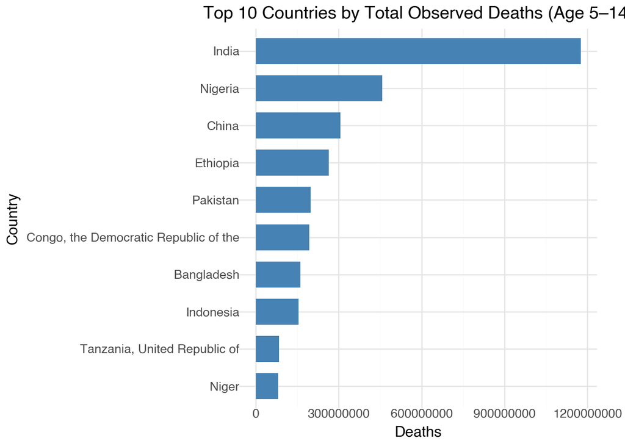

```python
from plotnine import *

df_pd = df.to_pandas()
agg_df = df_pd.groupby("country", as_index=False).agg({"obs_value": "sum"})
top10_df = agg_df.sort_values("obs_value", ascending=False).head(10)

bar_plot = (
    ggplot(top10_df)
    + aes(x='reorder(country, obs_value)', y='obs_value')
    + geom_bar(stat='identity', width=0.7, fill='steelblue')
    + coord_flip()
    + ggtitle("Top 10 Countries by Total Observed Deaths (Age 5–14)")
    + labs(x='Country', y='Deaths')
    + theme_minimal()
    + theme(
        axis_title=element_text(size=12, weight='bold'),
        axis_text=element_text(size=10),
        plot_title=element_text(size=14, weight='bold')
    )
)
bar_plot
```

**This horizontal bar chart shows the top 10 countries based on the highest number of deaths.**

## Visualization 3: Scatter Plot with Trend Line

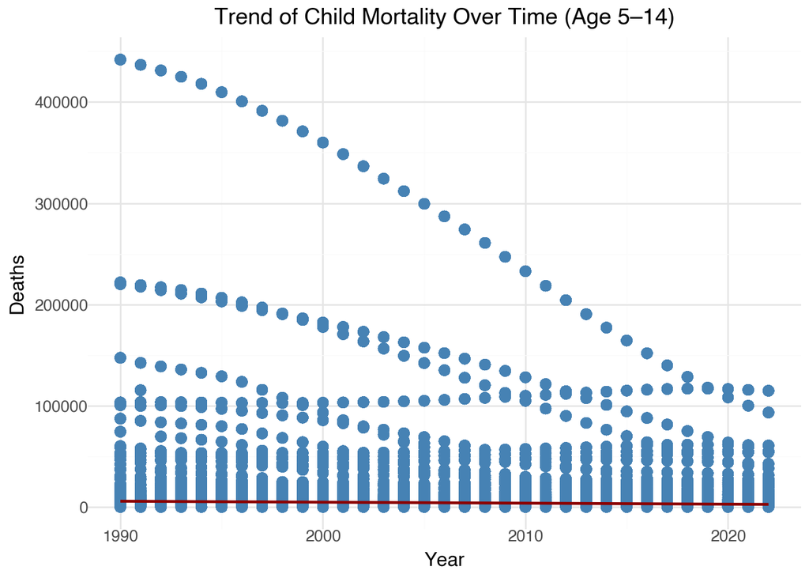

```python
from plotnine import ggplot, aes, geom_point, geom_smooth, ggtitle, theme_minimal, labs, theme, element_text

plot = (
    ggplot(df_pd)
    + aes(x="Year", y="obs_value")
    + geom_point(color="steelblue", size=3, alpha=0.7)
    + geom_smooth(method="lm", color="darkred", fill="salmon", alpha=0.3)
    + ggtitle("Trend of Child Mortality Over Time (Age 5–14)")
    + labs(x="Year", y="Deaths")
    + theme_minimal()
    + theme(
        axis_title=element_text(size=12, weight='bold'),
        plot_title=element_text(size=14, weight='bold', ha='center'),
        axis_text=element_text(size=10)
    )
)
plot
```

**This scatter plot shows the trend of mortality over time for children aged 5–14 years.**

## Visualization 4: Time Series for Top 10 Countries

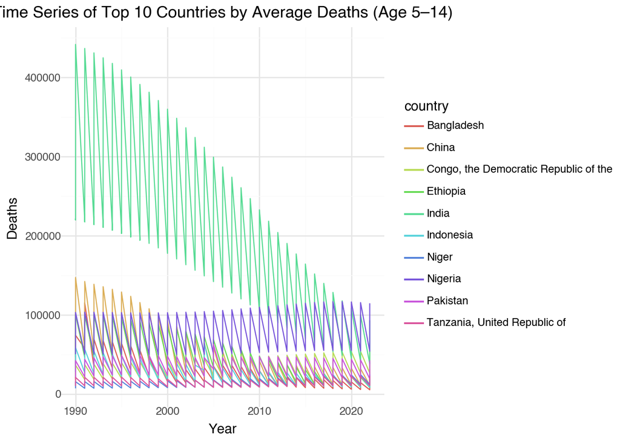

```python
data = df.to_pandas()
top_countries = data.groupby('country')['obs_value'].mean().sort_values(ascending=False).head(10).index
filtered_data = data[data['country'].isin(top_countries)]

plot = (
    ggplot(filtered_data)
    + aes(x='Year', y='obs_value', group='country', color='country')
    + geom_line()
    + ggtitle("Time Series of Top 10 Countries by Average Deaths (Age 5–14)")
    + labs(x='Year', y='Deaths')
    + theme_minimal()
)
plot
```

**This line chart displays the mortality trends for the top 10 countries across years.**

## Visualization 5: Treemap of Top 20 Countries

```python
import plotly.express as px

grouped = df_pd.groupby('country', as_index=False).agg({'obs_value': 'max'})
top20 = grouped.nlargest(20, 'obs_value')

fig = px.treemap(
    top20,
    path=['country'],
    values='obs_value',
    color='obs_value',
    color_continuous_scale='YlOrBr',
    title="Treemap: Top 20 Countries by Deaths (Age 5–14)"
)

fig.update_layout(
    coloraxis_colorbar_title='Deaths (Age 5–14)',
    paper_bgcolor='mintcream',
    plot_bgcolor='whitesmoke'
)
fig.show()
```

[interactive chart not shown]

**This treemap highlights the 20 countries with the highest observed deaths among children aged 5–14 years.**

## Visualization 6: Sunburst Chart - Country → Year Breakdown

```python
import plotly.express as px

# Group by country and year
grouped = df_pd.groupby(['country', 'Year'], as_index=False).agg({'obs_value': 'sum'})

# Select top 20 countries
top_countries = (
    grouped.groupby('country')['obs_value']
    .sum()
    .sort_values(ascending=False)
    .head(20)
    .index
)

# Filter only top 20 countries
filtered_grouped = grouped[grouped['country'].isin(top_countries)].copy()

# Custom hover text
filtered_grouped['hover_info'] = (
    'Country: ' + filtered_grouped['country'] +
    '<br>Year: ' + filtered_grouped['Year'].astype(str) +
    '<br>Deaths (Age 5–14): ' + filtered_grouped['obs_value'].round(0).astype(str)
)

# Create the Sunburst Chart
fig = px.sunburst(
    filtered_grouped,
    path=['country', 'Year'],   # 👈 Country ➔ Year
    values='obs_value',
    color='obs_value',
    color_continuous_scale=px.colors.sequential.Pinkyl,  # 👈 Pink color gradient
    title='🌸 Sunburst Chart: Top 20 Countries ➔ Year ➔ Child Mortality (Age 5–14)',
    hover_data={'hover_info': True}
)

# Update layout
fig.update_layout(
    title_x=0.5,
    title_font_size=24,
    title_font_family="Arial",
    margin=dict(t=60, l=30, r=30, b=30),
    paper_bgcolor='whitesmoke',
    plot_bgcolor='whitesmoke',
    coloraxis_colorbar_title='Deaths (Age 5–14)',
    font=dict(family="Arial", size=14)
)

# Update traces
fig.update_traces(
    hovertemplate='%{customdata[0]}<extra></extra>',
    textinfo="label+percent entry",
    insidetextorientation='radial'
)

fig.show()
```

[interactive chart not shown]

**This sunburst chart shows the breakdown of deaths by country and year among the top 20 countries.**

## Conclusion

The report highlights serious disparities in child mortality rates across countries. Specific nations show persistently high death rates for children aged 5–14, calling for urgent healthcare policy reforms. Investing in better healthcare access and disease prevention strategies can significantly reduce preventable child deaths worldwide.